# Redlining Text Analysis

Updated: 2020-04-20

## Introduction

tidytext instructions/example: https://cran.r-project.org/web/packages/tidytext/vignettes/tidytext.html

## Read Data

Get data from the area description forms and combine data from several fields into one to be used in this analysis.

```r
# get data
df_area_description_text <- read_csv(here('area-descriptions',
                                          '_redline_combined_area-descriptions.csv'))

# join the favorable and detrimental influences columns
df_area_description_text <- df_area_description_text %>%
    mutate(area_description_all = paste(area_terrain,
                                  area_favorable_influences,
                                  area_detrimental_influences,
                                  clarifying_remarks,
                                  area_description,
                                  sep = ' | ')) %>%
    select(city, holc_id, holc_grade, area_description_all)
```

## Format Data for Text Analysis

Restructure as one-token-per-row format (i.e., one word per row), then remove some stop words and common place names.

```r
# restructure as one-token-per-row format (i.e., one word per row)
tidy_all_influences <- df_area_description_text %>%
    unnest_tokens(output = word, input = area_description_all)

# remove stop words and common place names
cleaned_all_influences <- tidy_all_influences %>%
    anti_join(get_stopwords()) %>%
    filter(!(word %in% c('na', 'san', 'francisco', 'los', 'angeles', 1:999999)))
```

## Analysis Part 1 - Individual Words: Counts, Sentiment Scores, and Wordclouds

### Most Common Words

#### Most common words by HOLC grade (top 10)

```r
# find the most common words
top_by_grade <- cleaned_all_influences %>%
    group_by(holc_grade) %>%
    count(word) %>%
    top_n(10, n)
top_by_grade
```

```
## # A tibble: 40 x 3
## # Groups:   holc_grade [4]
##    holc_grade word              n
##    <chr>      <chr>         <int>
##  1 A          architectural    74
##  2 A          area            234
##  3 A          construction    133
##  4 A          deed             77
##  5 A          grade            88
##  6 A          hazards          78
##  7 A          high             86
##  8 A          improved         65
##  9 A          land             78
## 10 A          years            90
## # ... with 30 more rows
```

### Sentiment Scores

#### Most common positive words by HOLC grade (top 5)

```r
# most common positive words
positive <- get_sentiments("bing") %>%
    filter(sentiment == "positive")

top_positive_by_grade <- tidy_all_influences %>%
    semi_join(positive) %>%
    group_by(holc_grade) %>%
    count(word) %>%
    top_n(5, n)
top_positive_by_grade
```

```
## # A tibble: 20 x 3
## # Groups:   holc_grade [4]
##    holc_grade word             n
##    <chr>      <chr>        <int>
##  1 A          available       54
##  2 A          favorable       31
##  3 A          improved        65
##  4 A          improvements    61
##  5 A          readily         34
##  6 B          available      131
##  7 B          good           127
##  8 B          improved       150
##  9 B          improvements   203
## 10 B          readily         94
## 11 C          available      170
## 12 C          good           107
## 13 C          improved       202
## 14 C          improvements   282
## 15 C          readily        121
## 16 D          available       62
## 17 D          convenience     31
## 18 D          improved        83
## 19 D          improvements   113
## 20 D          readily         39
```

#### Most common negative words by HOLC grade (top 5)

```r
# most common negative words
negative <- get_sentiments("bing") %>%
    filter(sentiment == "negative")

top_negative_by_grade <- tidy_all_influences %>%
    semi_join(negative) %>%
    group_by(holc_grade) %>%
    count(word) %>%
    top_n(5, n)
top_negative_by_grade
```

```
## # A tibble: 21 x 3
## # Groups:   holc_grade [4]
##    holc_grade word            n
##    <chr>      <chr>       <int>
##  1 A          detrimental    10
##  2 A          limited        11
##  3 A          restricted     25
##  4 A          steep          18
##  5 A          subversive     14
##  6 B          detrimental    30
##  7 B          hazard         27
##  8 B          inadequate     26
##  9 B          lack           51
## 10 B          restricted     37
## # ... with 11 more rows
```

#### Overall positive and negative word summary

```r
bing <- get_sentiments("bing")

# Most common positive and negative words
bing_word_counts <- tidy_all_influences %>%
    inner_join(bing) %>%
    count(word, sentiment, sort = TRUE)

bing_word_counts
```

```
## # A tibble: 524 x 3
##    word         sentiment     n
##    <chr>        <chr>     <int>
##  1 improvements positive    659
##  2 improved     positive    500
##  3 available    positive    417
##  4 readily      positive    288
##  5 good         positive    280
##  6 favorable    positive    215
##  7 well         positive    185
##  8 better       positive    164
##  9 convenience  positive    143
## 10 pride        positive    114
## # ... with 514 more rows
```

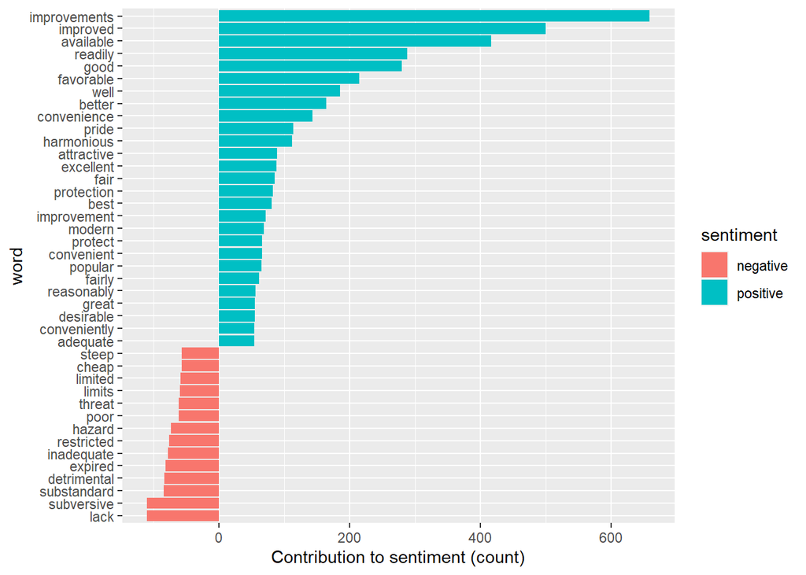

```r
bing_word_counts %>%
    filter(n > 50) %>%
    mutate(n = ifelse(sentiment == "negative", -n, n)) %>%
    mutate(word = reorder(word, n)) %>%
    ggplot(aes(word, n, fill = sentiment)) +
    geom_col() +
    coord_flip() +
    labs(y = "Contribution to sentiment (count)")
```

#### Sentiment by HOLC and city

Find a sentiment score for each word, then count the number of positive and negative words by HOLC grade and city

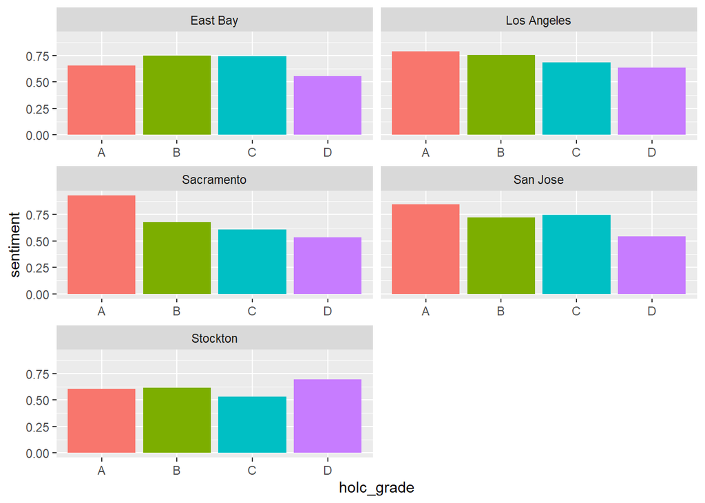

```r
# examine how sentiment changes - find a sentiment score for each word using the same lexicon, then count the number of positive and negative words in defined groups

holc_sentiment <- tidy_all_influences %>%
    inner_join(bing) %>%
    count(city, holc_grade, sentiment) %>%
    spread(sentiment, n, fill = 0) %>%
    mutate(sentiment = (positive) / (positive + negative))


ggplot(holc_sentiment, aes(holc_grade, sentiment, fill = holc_grade)) +
    geom_bar(stat = "identity", show.legend = FALSE) +
    facet_wrap(~city, ncol = 2, scales = "free_x")
```

### Wordclouds

#### Basic wordcloud

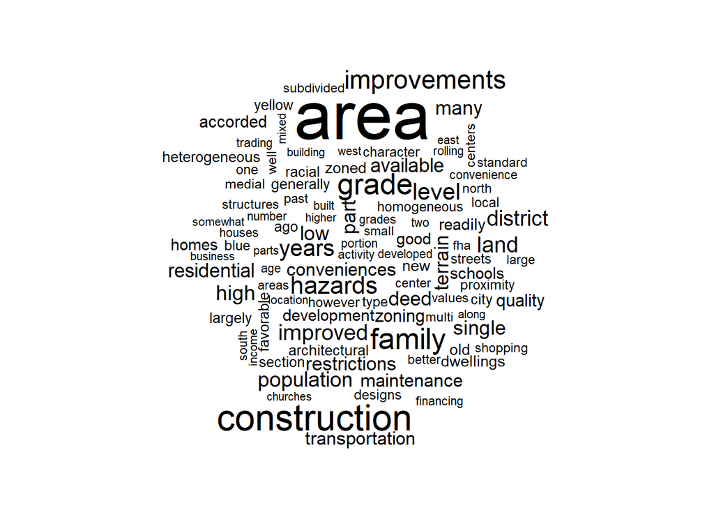

```r
# wordcloud
cleaned_all_influences %>%
    count(word) %>%
    with(wordcloud(word, n, max.words = 100))
```

#### Wordcloud with sentiment

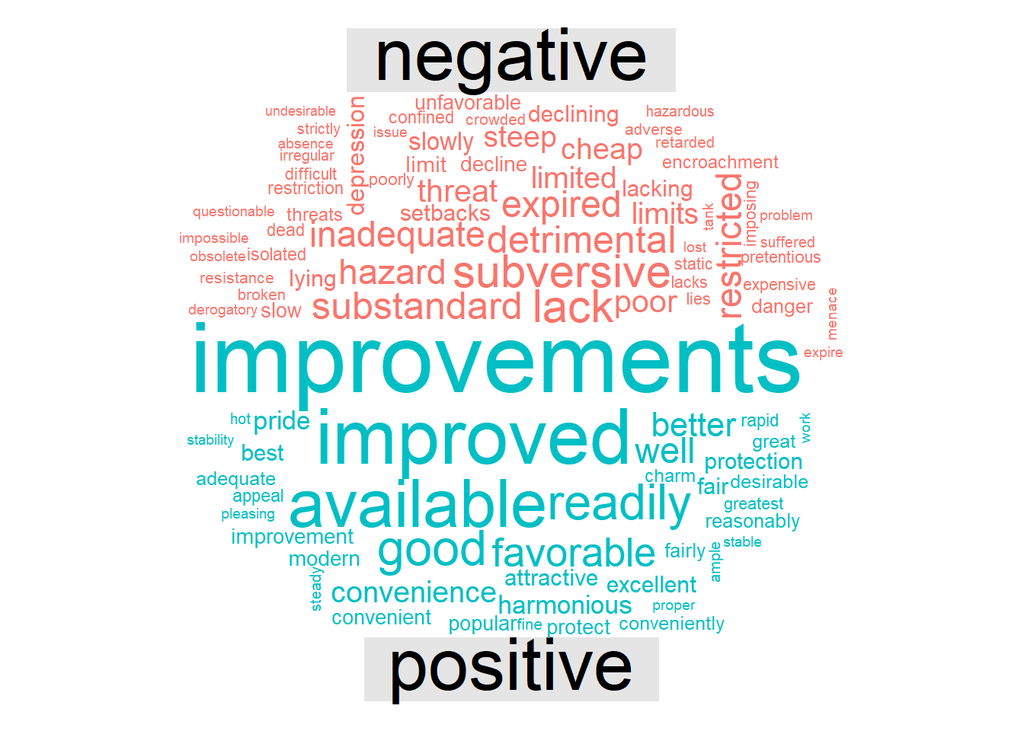

```r
# wordcloud with sentiment
tidy_all_influences %>%
    inner_join(bing) %>%
    count(word, sentiment, sort = TRUE) %>%
    acast(word ~ sentiment, value.var = "n", fill = 0) %>%
    comparison.cloud(colors = c("#F8766D", "#00BFC4"),
                     max.words = 100)
```

```r
# alternate grouping - just shows number of HOLC polygons by city
# tidy_types <- df_area_description_text %>%
#     unnest_tokens(output = text, input = area_description_all, token = 'paragraphs') %>%
#     ungroup()
#
# tidy_types %>%
#     group_by(city) %>%
#     summarise(count = n())
```

### Most Negative HOLC Grade by City

Most negative holc grades by city, measured by ratio of negative words to total words

```r
# most negative holc grades by city (ratio of negative words to total words)
bingnegative <- get_sentiments("bing") %>%
    filter(sentiment == "negative")

wordcounts <- tidy_all_influences %>%
    group_by(city, holc_grade) %>%
    summarize(words = n())

tidy_all_influences %>%
    semi_join(bingnegative) %>%
    group_by(city, holc_grade) %>%
    summarize(negativewords = n()) %>%
    left_join(wordcounts, by = c("city", "holc_grade")) %>%
    mutate(ratio = negativewords/words) %>%
    top_n(2)
```

```
## # A tibble: 10 x 5
## # Groups:   city [5]
##    city        holc_grade negativewords words  ratio
##    <chr>       <chr>              <int> <int>  <dbl>
##  1 East Bay    A                     32  1312 0.0244
##  2 East Bay    D                     69  2947 0.0234
##  3 Los Angeles C                    693 30190 0.0230
##  4 Los Angeles D                    229  9013 0.0254
##  5 Sacramento  C                     99  4281 0.0231
##  6 Sacramento  D                     37  1069 0.0346
##  7 San Jose    B                     14   968 0.0145
##  8 San Jose    D                     35  1515 0.0231
##  9 Stockton    A                     13   513 0.0253
## 10 Stockton    C                     56  1755 0.0319
```

## Analysis Part 2 - N-grams: Network Graphs

Groups of words appearing together.

### Most common bigrams (top 10)

```r
## PART 2 ------------------------------
# https://www.tidytextmining.com/ngrams.html
# tokenizing by n-gram
all_bigrams <- df_area_description_text %>%
    unnest_tokens(output = bigram, input = area_description_all, token = "ngrams", n = 2)

# count / filter
all_bigrams %>%
    count(bigram, sort = TRUE) %>%
    head(n = 10)
```

```
## # A tibble: 10 x 2
##    bigram                   n
##    <chr>                <int>
##  1 na na                 1262
##  2 the area               831
##  3 of the                 715
##  4 this area              640
##  5 area is                584
##  6 construction hazards   466
##  7 it is                  443
##  8 in the                 438
##  9 single family          426
## 10 na terrain             407
```

#### Clean up bigrams (top 10)

```r
# remove cases where either is a stop-word
bigrams_separated <- all_bigrams %>%
    separate(bigram, c("word1", "word2"), sep = " ")

bigrams_filtered <- bigrams_separated %>%
    filter(!word1 %in% c(stop_words$word, 'na', 'san', 'francisco', 'los', 'angeles', 1:999999)) %>%
    filter(!word2 %in% c(stop_words$word, 'na', 'san', 'francisco', 'los', 'angeles', 1:999999))

# new bigram counts:
bigram_counts <- bigrams_filtered %>%
    count(word1, word2, sort = TRUE)
bigram_counts %>% head(n = 10)
```

```
## # A tibble: 10 x 3
##    word1         word2            n
##    <chr>         <chr>        <int>
##  1 construction  hazards        466
##  2 single        family         426
##  3 land          improved       405
##  4 deed          restrictions   331
##  5 terrain       level          308
##  6 hazards       land           304
##  7 family        residential    210
##  8 architectural designs        195
##  9 yellow        grade          175
## 10 family        dwellings      155
```

```r
# unite
bigrams_united <- bigrams_filtered %>%
    unite(bigram, word1, word2, sep = " ")
bigrams_united %>% head(n = 10)
```

```
## # A tibble: 10 x 4
##    city     holc_id holc_grade bigram
##    <chr>    <chr>   <chr>      <chr>
##  1 East Bay A1      A          steep slopes
##  2 East Bay A1      A          view home
##  3 East Bay A1      A          home locations
##  4 East Bay A1      A          landscaping streets
##  5 East Bay A1      A          streets platted
##  6 East Bay A1      A          minimize grades
##  7 East Bay A1      A          grades inspiring
##  8 East Bay A1      A          inspiring view
##  9 East Bay A1      A          view locations
## 10 East Bay A1      A          improved streets
```

### Trigrams

10 most common tri-grams

```r
# trigrams
df_area_description_text %>%
    select(city, holc_id, holc_grade, area_description_all) %>%
    unnest_tokens(output = trigram, input = area_description_all, token = "ngrams", n = 3) %>%
    separate(trigram, c("word1", "word2", "word3"), sep = " ") %>%
    filter(!word1 %in% c(stop_words$word, 'na', 'san', 'francisco'),
           !word2 %in% c(stop_words$word, 'na', 'san', 'francisco'),
           !word3 %in% c(stop_words$word, 'na', 'san', 'francisco')) %>%
    count(word1, word2, word3, sort = TRUE) %>%
    head(n = 10)
```

```
## # A tibble: 10 x 4
##    word1        word2       word3            n
##    <chr>        <chr>       <chr>        <int>
##  1 hazards      land        improved       303
##  2 construction hazards     land           294
##  3 single       family      residential    151
##  4 single       family      dwellings       88
##  5 medial       yellow      grade           71
##  6 family       residential conveniences    68
##  7 low          yellow      grade           67
##  8 fha          title       ii              57
##  9 zoned        single      family          56
## 10 land         improved    90              55
```

### TF IDF?

```r
# analyze bigrams
    bigram_tf_idf <- bigrams_united %>%
        count(holc_grade, bigram) %>%
        bind_tf_idf(bigram, holc_grade, n) %>%
        arrange(desc(tf_idf))

    bigram_tf_idf %>%
        head(n = 10)
```

```
## # A tibble: 10 x 6
##    holc_grade bigram           n      tf   idf  tf_idf
##    <chr>      <chr>        <int>   <dbl> <dbl>   <dbl>
##  1 D          red grade       70 0.0217  1.39  0.0300
##  2 D          medial red      35 0.0108  1.39  0.0150
##  3 C          yellow grade   173 0.0198  0.693 0.0137
##  4 A          green grade     53 0.0194  0.693 0.0134
##  5 B          blue grade     125 0.0182  0.693 0.0126
##  6 D          low red         25 0.00774 1.39  0.0107
##  7 B          medial blue     49 0.00713 1.39  0.00988
##  8 A          medial green    14 0.00512 1.39  0.00710
##  9 C          low yellow      85 0.00970 0.693 0.00673
## 10 A          low green       26 0.00951 0.693 0.00659
```

### Network Graphs

Arrange the words into a network, or “graph” (combination of connected nodes). A graph can be constructed from a tidy object since it has three variables:

- from: the node an edge is coming from
- to: the node an edge is going towards
- weight: A numeric value associated with each edge

#### Basic graph

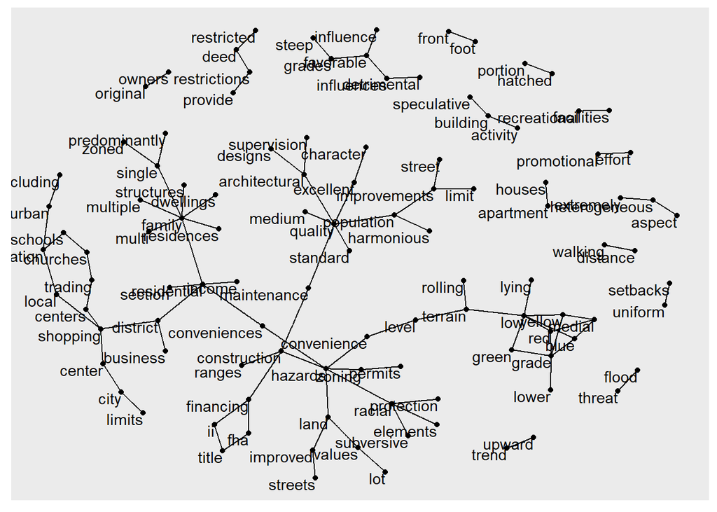

```r
# Visualizing a network of bigrams with ggraph
    # filter for only relatively common combinations
    bigram_graph <- bigram_counts %>%
        filter(n > 20) %>%
        graph_from_data_frame()

    # make graph
    set.seed(2017)

    ggraph(bigram_graph, layout = "fr") +
        geom_edge_link() +
        geom_node_point() +
        geom_node_text(aes(label = name), vjust = 1, hjust = 1)
```

#### Revised graph

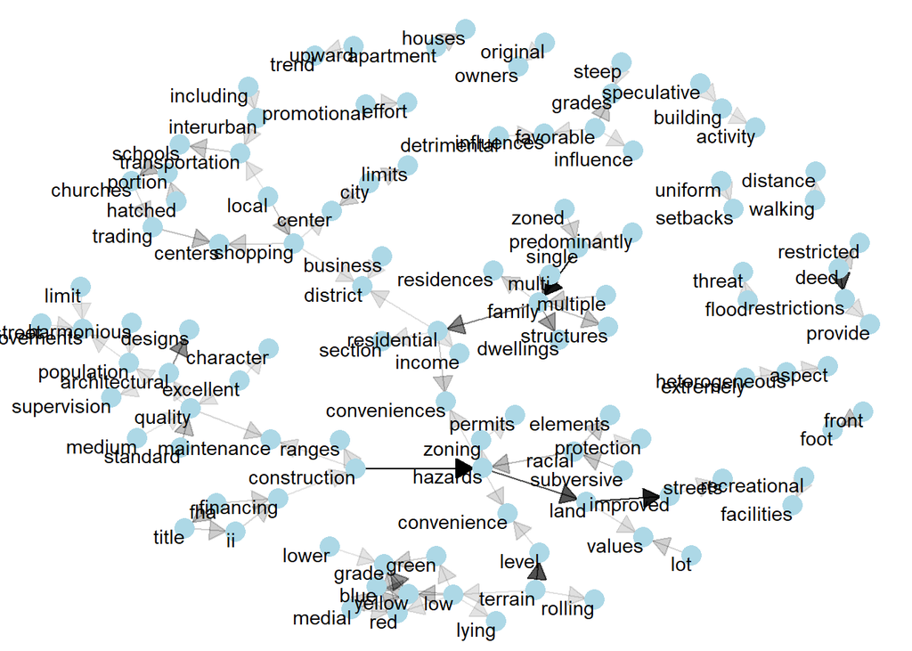

```r
# a few polishing operations to make a better looking graph
    set.seed(2016)

    a <- grid::arrow(type = "closed", length = unit(.15, "inches"))

    ggraph(bigram_graph, layout = "fr") +
        geom_edge_link(aes(edge_alpha = n), show.legend = FALSE,
                       arrow = a, end_cap = circle(.07, 'inches')) +
        geom_node_point(color = "lightblue", size = 5) +
        geom_node_text(aes(label = name), vjust = 1, hjust = 1) +
        theme_void()
```

#### Graphs by HOLC grade

HOLC grade A

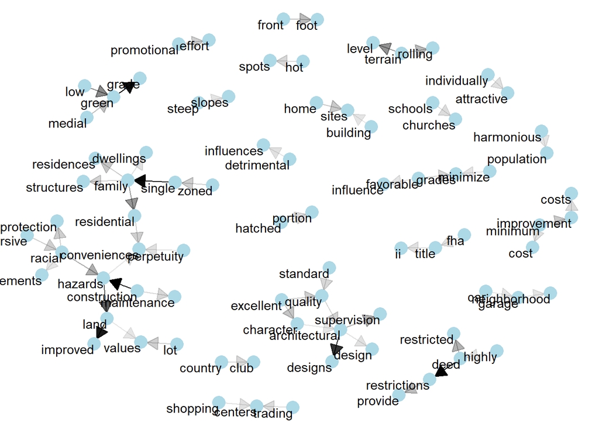

```r
# HOLC Grade A
    bigram_graph_A <- bigrams_filtered %>%
        filter(holc_grade == 'A') %>%
        count(word1, word2, sort = TRUE) %>%
        filter(n > 5) %>%
        graph_from_data_frame()

# graph
    ggraph(bigram_graph_A, layout = "fr") +
        geom_edge_link(aes(edge_alpha = n), show.legend = FALSE,
                       arrow = a, end_cap = circle(.07, 'inches')) +
        geom_node_point(color = "lightblue", size = 5) +
        geom_node_text(aes(label = name), vjust = 1, hjust = 1) +
        theme_void()
```

HOLC grade B

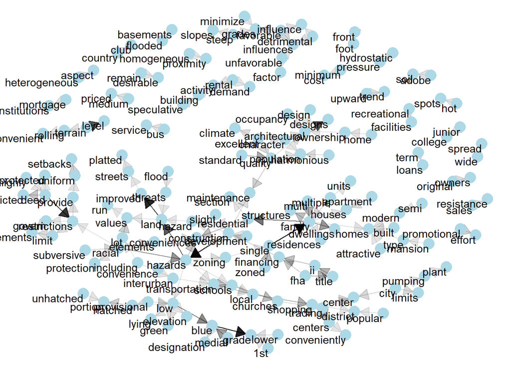

```r
    bigram_graph_B <- bigrams_filtered %>%
        filter(holc_grade == 'B') %>%
        #filter(holc_grade == 'A' | holc_grade == 'B') %>%
        count(word1, word2, sort = TRUE) %>%
        filter(n > 5) %>%
        graph_from_data_frame()
# graph
    ggraph(bigram_graph_B, layout = "fr") +
        geom_edge_link(aes(edge_alpha = n), show.legend = FALSE,
                       arrow = a, end_cap = circle(.07, 'inches')) +
        geom_node_point(color = "lightblue", size = 5) +
        geom_node_text(aes(label = name), vjust = 1, hjust = 1) +
        theme_void()
```

HOLC grade C

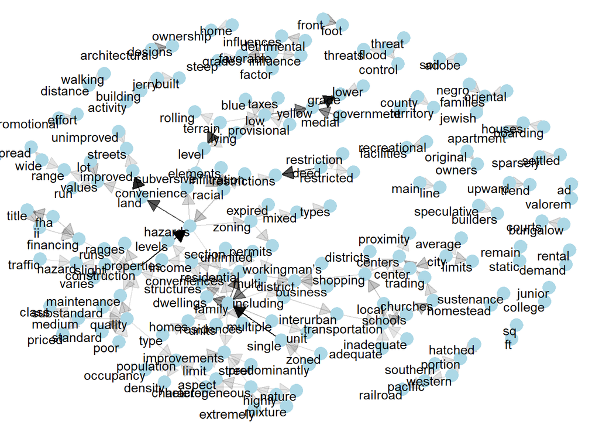

```r
    bigram_graph_C <- bigrams_filtered %>%
        filter(holc_grade == 'C') %>%
        count(word1, word2, sort = TRUE) %>%
        filter(n > 5) %>%
        graph_from_data_frame()
# graph
    ggraph(bigram_graph_C, layout = "fr") +
        geom_edge_link(aes(edge_alpha = n), show.legend = FALSE,
                       arrow = a, end_cap = circle(.07, 'inches')) +
        geom_node_point(color = "lightblue", size = 5) +
        geom_node_text(aes(label = name), vjust = 1, hjust = 1) +
        theme_void()
```

HOLC grade D

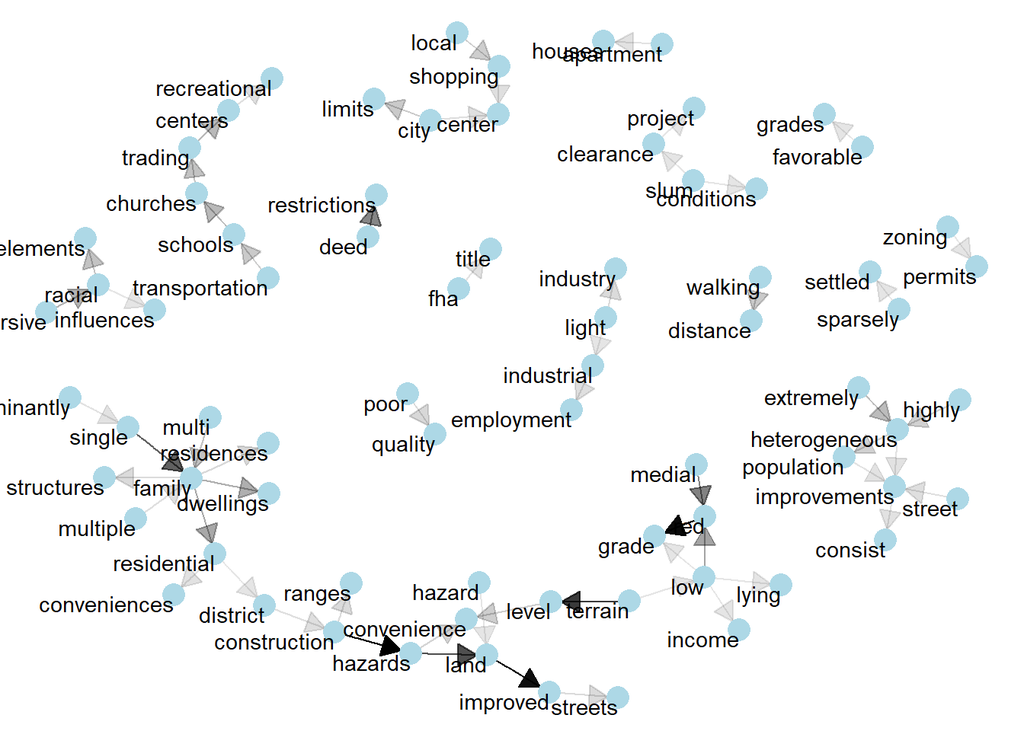

```r
    bigram_graph_D <- bigrams_filtered %>%
        filter(holc_grade == 'D') %>%
        count(word1, word2, sort = TRUE) %>%
        filter(n > 5) %>%
        graph_from_data_frame()
# graph
    ggraph(bigram_graph_D, layout = "fr") +
        geom_edge_link(aes(edge_alpha = n), show.legend = FALSE,
                       arrow = a, end_cap = circle(.07, 'inches')) +
        geom_node_point(color = "lightblue", size = 5) +
        geom_node_text(aes(label = name), vjust = 1, hjust = 1) +
        theme_void()
```

HOLC grade A and B

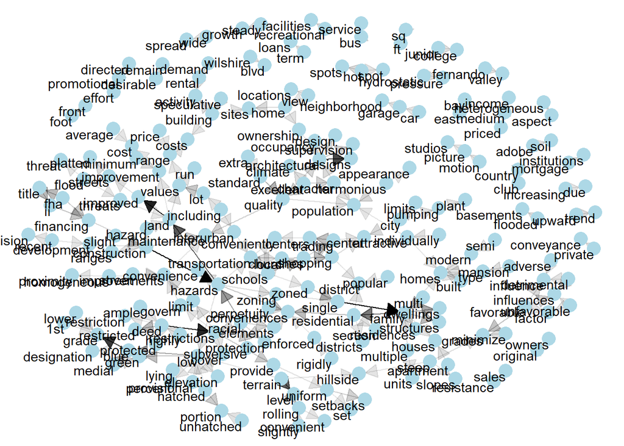

```r
    bigram_graph_A_B <- bigrams_filtered %>%
        filter(holc_grade == 'A' | holc_grade == 'B') %>%
        count(word1, word2, sort = TRUE) %>%
        filter(n > 5) %>%
        graph_from_data_frame()
# graph
    ggraph(bigram_graph_A_B, layout = "fr") +
        geom_edge_link(aes(edge_alpha = n), show.legend = FALSE,
                       arrow = a, end_cap = circle(.07, 'inches')) +
        geom_node_point(color = "lightblue", size = 5) +
        geom_node_text(aes(label = name), vjust = 1, hjust = 1) +
        theme_void()
```

HOLC grade C and D

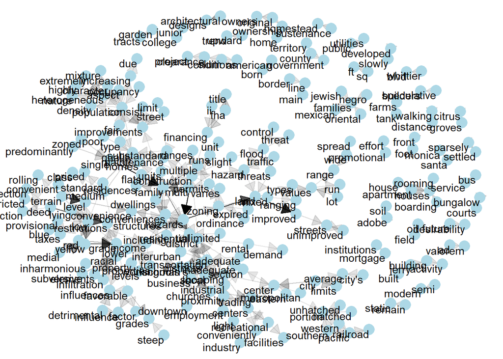

```r
    bigram_graph_C_D <- bigrams_filtered %>%
        filter(holc_grade == 'C' | holc_grade == 'D') %>%
        count(word1, word2, sort = TRUE) %>%
        filter(n > 5) %>%
        graph_from_data_frame()
# graph
    ggraph(bigram_graph_C_D, layout = "fr") +
        geom_edge_link(aes(edge_alpha = n), show.legend = FALSE,
                       arrow = a, end_cap = circle(.07, 'inches')) +
        geom_node_point(color = "lightblue", size = 5) +
        geom_node_text(aes(label = name), vjust = 1, hjust = 1) +
        theme_void()
```

### Count and correlate co-occuring pairs of words

#### Most common co-occuring words (both occuring within a given HOLC ID)

```r
# Counting and correlating pairs of words within individual holc areas (summarize by grade?)
    cleaned_all_influences <- cleaned_all_influences %>%
        mutate('city_id' = paste(city, holc_id, sep = '-'))


    # count words co-occuring within sections
    word_pairs <- cleaned_all_influences %>%
        pairwise_count(word, city_id, sort = TRUE) %>%
        head(n = 10)
```

#### Words most often occuring with other words

Example: oil (top 10)

```r
    # find the words that most often occur with other words
    word_pairs %>% filter(item1 == 'oil') %>%
    head(n = 10)
```

```
## # A tibble: 0 x 3
## # ... with 3 variables: item1 <chr>, item2 <chr>, n <dbl>
```

Example: race (top 10)

```r
    # find the words that most often occur with other words
    word_pairs %>% filter(item1 == 'race') %>%
    head(n = 10)
```

```
## # A tibble: 0 x 3
## # ... with 3 variables: item1 <chr>, item2 <chr>, n <dbl>
```

Example: infiltration (top 10)

```r
    # find the words that most often occur with other words
    word_pairs %>% filter(item1 == 'infiltration') %>%
    head(n = 10)
```

```
## # A tibble: 0 x 3
## # ... with 3 variables: item1 <chr>, item2 <chr>, n <dbl>
```

### Pairwise Correlation

Calculate correlation (ratio of co-occurence plus co-non-occurence vs overall occurence) #### word correlation with “racial” (showing top 10)

```r
# Pairwise correlation
    # we need to filter for at least relatively common words first
    word_cors <- cleaned_all_influences %>%
        group_by(word) %>%
        filter(n() >= 2) %>%
        pairwise_cor(word, city_id, sort = TRUE)

    # find the words most correlated with another word using a filter operation
    word_cors %>% filter(item1 == 'racial') %>% head(n = 10)
```

```
## # A tibble: 10 x 3
##    item1  item2         correlation
##    <chr>  <chr>               <dbl>
##  1 racial subversive          0.411
##  2 racial protect             0.408
##  3 racial elements            0.406
##  4 racial deed                0.383
##  5 racial designs             0.369
##  6 racial provide             0.366
##  7 racial restrictions        0.355
##  8 racial architectural       0.343
##  9 racial terrain             0.321
## 10 racial improved            0.317
```

#### Correlation differences by holc grade

Word correlation for HOLC grade A (top 10)

```r
word_cors_A <- cleaned_all_influences %>%
    filter(holc_grade == 'A') %>%
    group_by(word) %>%
    filter(n() >= 2) %>%
    pairwise_cor(word, city_id, sort = TRUE)
word_cors_A %>% head(n = 10)
```

```
## # A tibble: 10 x 3
##    item1       item2     correlation
##    <chr>       <chr>           <dbl>
##  1 terrain     area              Inf
##  2 area        terrain           Inf
##  3 flooded     elevation           1
##  4 basements   elevation           1
##  5 times       elevation           1
##  6 tides       elevation           1
##  7 hydrostatic elevation           1
##  8 ameliorated elevation           1
##  9 pumping     elevation           1
## 10 operated    elevation           1
```

Word correlation for HOLC grade D (top 10)

```r
word_cors_D <- cleaned_all_influences %>%
    filter(holc_grade == 'D') %>%
    group_by(word) %>%
    filter(n() >= 2) %>%
    pairwise_cor(word, city_id, sort = TRUE)
word_cors_D %>% head(n = 10)
```

```
## # A tibble: 10 x 3
##    item1        item2        correlation
##    <chr>        <chr>              <dbl>
##  1 incorporated washington            1.
##  2 washington   incorporated          1.
##  3 channel      mormon                1.
##  4 mormon       channel               1.
##  5 handicapped  reputation            1.
##  6 reputation   handicapped           1.
##  7 church       close                 1.
##  8 close        church                1.
##  9 indebtedness secondary             1.
## 10 secondary    indebtedness          1.
```

#### Correlations by HOLC grade for specific words

Words correlated with “racial” for HOLC grades A and D

```r
word_cors_A %>% filter(item1 == 'racial') %>% head(n = 10)
```

```
## # A tibble: 10 x 3
##    item1  item2         correlation
##    <chr>  <chr>               <dbl>
##  1 racial homogeneous         0.532
##  2 racial land                0.512
##  3 racial maintenance         0.479
##  4 racial terrain             0.455
##  5 racial available           0.448
##  6 racial supervision         0.441
##  7 racial architectural       0.427
##  8 racial designs             0.426
##  9 racial grade               0.388
## 10 racial provide             0.381
```

```r
word_cors_D %>% filter(item1 == 'racial') %>% head(n = 10)
```

```
## # A tibble: 10 x 3
##    item1  item2        correlation
##    <chr>  <chr>              <dbl>
##  1 racial subversive         0.601
##  2 racial elements           0.578
##  3 racial influences         0.453
##  4 racial standpoint         0.353
##  5 racial inharmonious       0.315
##  6 racial warrant            0.315
##  7 racial group              0.271
##  8 racial red                0.262
##  9 racial amount             0.258
## 10 racial presence           0.247
```

Words correlated with “industry” for HOLC grades A and D

```r
word_cors_A %>% filter(item1 == 'industry') %>% head(n = 10)
```

```
## # A tibble: 0 x 3
## # ... with 3 variables: item1 <chr>, item2 <chr>, correlation <dbl>
```

```r
word_cors_D %>% filter(item1 == 'industry') %>% head(n = 10)
```

```
## # A tibble: 10 x 3
##    item1    item2         correlation
##    <chr>    <chr>               <dbl>
##  1 industry light               0.373
##  2 industry races               0.322
##  3 industry end                 0.277
##  4 industry fair                0.270
##  5 industry along               0.270
##  6 industry industrial          0.269
##  7 industry probably            0.265
##  8 industry predominating       0.265
##  9 industry residential         0.243
## 10 industry renders             0.225
```

#### Plot of correlations by HOLC grade for specific words

Top words correlated with “oil”, “poor”, “odors”, and “industry”.

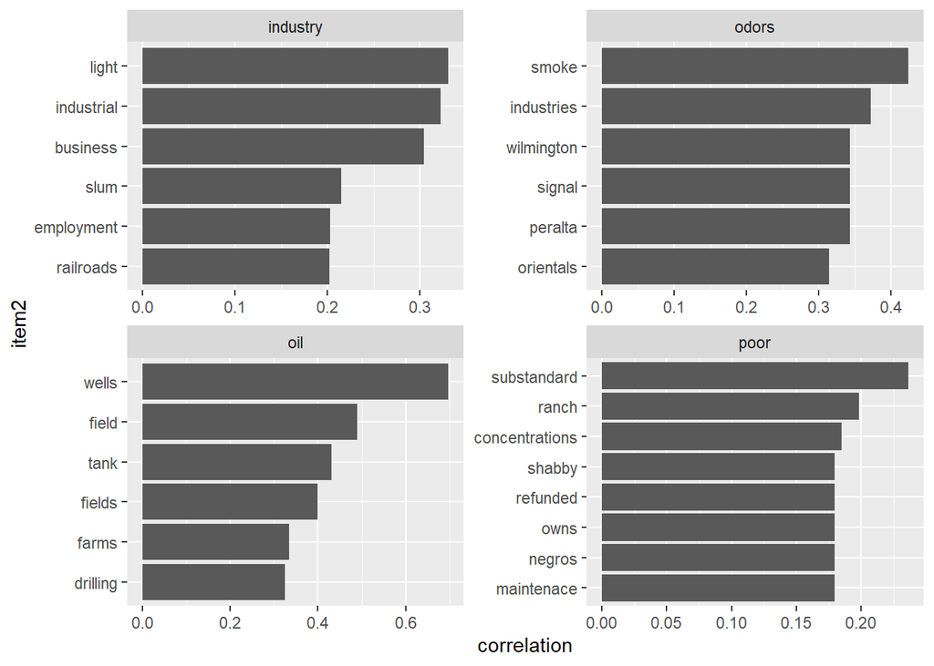

```r
# plot
word_cors %>%
    filter(item1 %in% c("oil", "poor", "odors", "industry")) %>%
    group_by(item1) %>%
    top_n(6) %>%
    ungroup() %>%
    mutate(item2 = reorder(item2, correlation)) %>%
    ggplot(aes(item2, correlation)) +
    geom_bar(stat = "identity") +
    facet_wrap(~ item1, scales = "free") +
    coord_flip()
```

Top words correlated with “racial”, “hazard”, “proximity”, and “encroachment”.

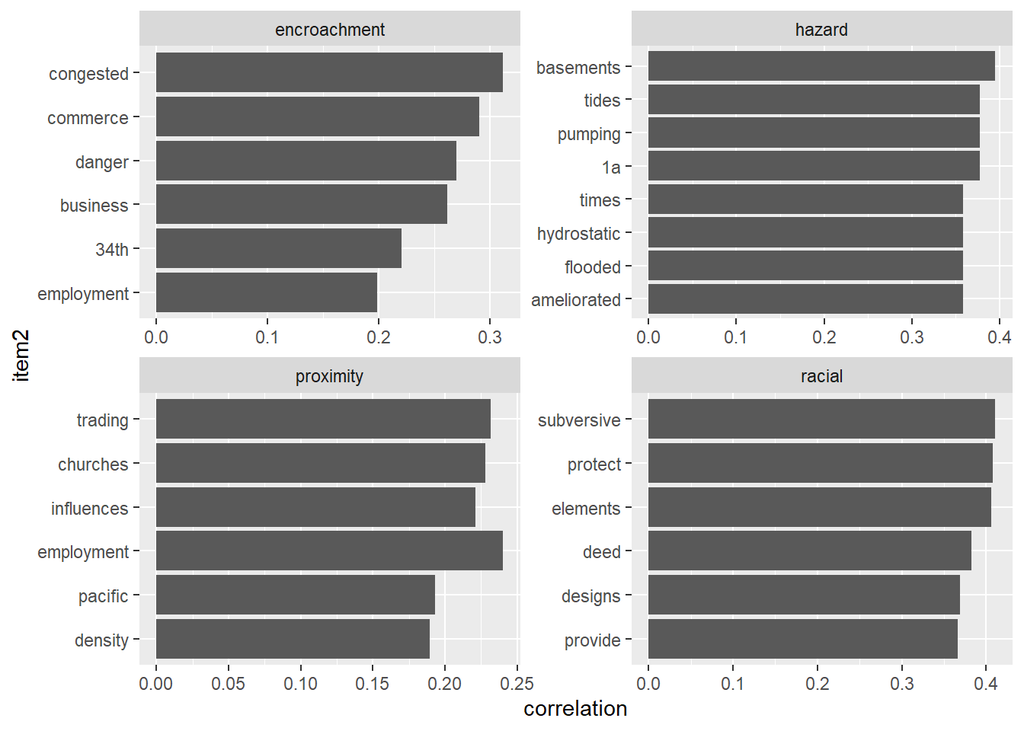

```r
    word_cors %>%
        filter(item1 %in% c("racial", "hazard", "proximity", "encroachment")) %>%
        group_by(item1) %>%
        top_n(6) %>%
        ungroup() %>%
        mutate(item2 = reorder(item2, correlation)) %>%
        ggplot(aes(item2, correlation)) +
        geom_bar(stat = "identity") +
        facet_wrap(~ item1, scales = "free") +
        coord_flip()
```

#### Visualize correlations and clusters of words with a graph

Doesn’t really work - dataset too big

```r
    # # visualize the correlations and clusters of words with a graph
    # # DOESN'T REALLY WORK - DATASET TOO BIG
    #
    # set.seed(2016)
    # word_cors_20 <- cleaned_all_influences %>%
    #     group_by(word) %>%
    #     filter(n() >= 200) %>%
    #     pairwise_cor(word, city_id, sort = TRUE)
    #
    # word_cors_20 %>%
    #     filter(correlation > .15) %>%
    #     graph_from_data_frame() %>%
    #     ggraph(layout = "fr") +
    #     geom_edge_link(aes(edge_alpha = correlation), show.legend = FALSE) +
    #     geom_node_point(color = "lightblue", size = 5) +
    #     geom_node_text(aes(label = name), repel = TRUE) +
    #     theme_void()
```